# Black Locust Species Distribution Modeling

Jeffrey Minucci

7/5/2017

## Introduction

Symbiotic N<sub>2</sub>-fixing plants can act as biogeochemical keystone species in forest ecosystems, providing massive inputs of nitrogen (N), typically during early succession. As a result, the presence of N<sub>2</sub>-fixers can cause increased N mineralization and nitrification rates, DIN pool sizes in soils, and productivity of non-fixing species (Minucci *et al.*, unpublished).

Despite the importance of symbiotic N<sub>2</sub>-fixers in regulating forest biogeochemistry, we lack an understanding of what factors control the distribution and abundance of these species. As a result, it is difficult to predict how global change factors will alter the presence of N<sub>2</sub>-fixers in forests, potentially leading to declines in some forests and invasion of N<sub>2</sub>-fixers into new regions.

In the eastern US, one widespread leguminuous N<sub>2</sub>-fixing tree, *R. pseudoacacia* (or black locust) plays a key role in driving forest productivity and recovery from disturbance (Minucci *et al.*, unpublished). Despite its importance, the factors controlling its distribution are poorly understood. The vast majority of leguminous N<sub>2</sub>-fixing tree species are either tropical or subtropical in range and the group is dominant in hot, arid regions. Yet, the distribution of *R. pseudoacacia* is centered in the Appalachian mountains, a wet temperate region. Two previous attempts to model the distribution of *R. pseudoacacia*, either alone (Iversion *et al.*, 2007) or with other leguminous N<sub>2</sub>-fixers had poor performance in predicting current distribution patterns.

Here we utilized the USDA FS Forest Inventory and Analysis (FIA) tree demographics dataset and machine learning methods to model *R. pseudoacacia* habitat suitability under current and future climate.

Our goals were to determine :

1. What climate, soil, geological, and forest structure factors drive the distribution of *R. pseudoacacia*?
2. How will the distribution of *R. pseudoacacia* be altered under future climate scenarios?

## Methods

### Data sources

#### Tree demographics: Forest Service FIA data

We used the most recent survey data for naturally regenerated forest plots in the Eastern US. We characterized *R. pseudoacacia* as either present or absent from each plot.

- Total plot number: 82,023 plots
- Plots with *R. pseudoacacia present: 2586 (3.2%)

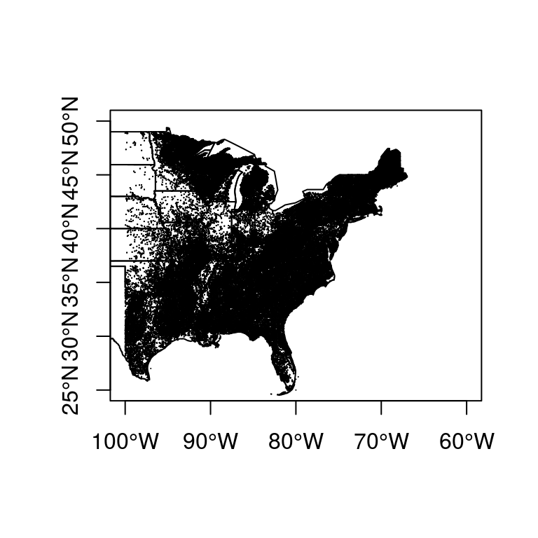

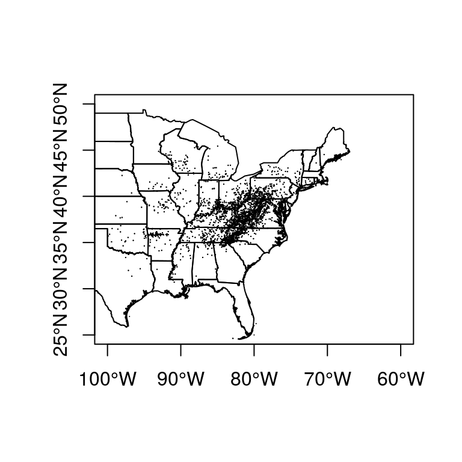

**All natural forest plots (left), and natural forest plots where *R. pseudoacacia* was present (right)**

#### Forest structure

From the Forest Service FIA dataset, we extracted data on:

- Elevation
- Slope
- Aspect
- Stand Age
- Presence of fire disturbance

We also included annual maximum green vegetation fraction (MGVF), a MODIS-based measurement of greenness (1 km<sup>2</sup> resolution).

#### Climate data

For current climate data, we used **WorldClim 2.0** bioclimatic variables with 30 seconds (~1 km<sup>2</sup>) resolution.

For projected climate in 2050, we used bioclimatic varibles extracted from all **CMIP5** general circulation models under the **RCP 8.5** pathway.

#### Geological data

To capture differences in parent material, we used:

- **USGS** classifications of parent material primary and secondary rock types

To represent more general differences in surface lithology we used:

- **USGS** maps of surfacial lithology (e.g. clayey glacial till, colluvial sediment)

#### Soil data

We used the Harominzed World Soil Database to extract the following soil features:

- pH
- Cation exchange capacity (CEC)
- USDA soil texture classification
- Organic carbon content

### Statistical modeling

We used gradient boosted classification trees to model the liklihood of *R. pseudoacacia* presence at each plot. This method allowed us to automate parameter selection and the structure of high-level interactions between parameters.

**Potential predictors:**

- BIO1 = Annual Mean Temperature
- BIO2 = Mean Diurnal Range (Mean of monthly (max temp - min temp))
- BIO3 = Isothermality (BIO2/BIO7) (* 100)
- BIO4 = Temperature Seasonality (standard deviation *100)
- BIO5 = Max Temperature of Warmest Month
- BIO6 = Min Temperature of Coldest Month
- BIO7 = Temperature Annual Range (BIO5-BIO6)
- BIO8 = Mean Temperature of Wettest Quarter
- BIO9 = Mean Temperature of Driest Quarter
- BIO10 = Mean Temperature of Warmest Quarter
- BIO11 = Mean Temperature of Coldest Quarter
- BIO12 = Annual Precipitation
- BIO13 = Precipitation of Wettest Month
- BIO14 = Precipitation of Driest Month
- BIO15 = Precipitation Seasonality (Coefficient of Variation)
- BIO16 = Precipitation of Wettest Quarter
- BIO17 = Precipitation of Driest Quarter
- BIO18 = Precipitation of Warmest Quarter
- BIO19 = Precipitation of Coldest Quarter
- Longitude
- Latitude
- Elevation
- Stand age
- Slope
- Aspect
- Presence of fire disturbance (yes/no)
- Maximum green vegetation fraction (MGVF)
- Surficial lithography
- Parent material primary rock type
- Parent material secondary rock type
- Soil cation exchange capacity (CEC)
- Soil pH
- Soil USDA texture classification
- Soil organic carbon

We split our data into model training (80%) and test (20%) sets. Boosted classification trees were fit to the training set, with optimal hyperparameters determined using five repeats of five-fold cross validation and a random grid search. Goodness of fit was calculated with **AUROC**, the area under the receiver operating characteristic (ROC) curve.

**Optimial hyperparameters were determined to be:**

- Interaction depth = 32
- Minimum observations in a node = 12
- Number of trees = 800
- Learning rate = 0.01

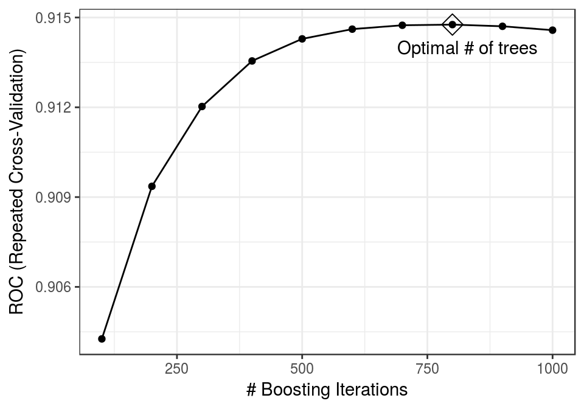

**Trajectory of fit versus number of trees**

## Results

### Model performance

Our main assessment of model performance is **AUROC**, or area under the receiver operating characteristic (ROC) curve. This metric takes into account both sensitivity (true positive rate) and specificity (true negative rate) and is preferable to classification accuracy (%) when positive and negative outcomes are imbalanced (and in our case, *R. pseudoacacia* is present in only ~3% of plots).

The best possible AUROC is 1, while the worst possible AUROC (a null model) would be 0.5.

#### Model accuracy

| Metric | Value |
| --- | --- |
| Training set AUROC (cross-validated) | 0.915 |
| Test set AUROC | 0.908 |

### What factors were most important in determining presence of *R. pseudoacacia*?

| Variable | Importance |
| --- | --- |
| Annual mean temperature | 100.0 |
| Max temp. of warmest month | 81.2 |
| Primary parent rock type | 75.1 |
| Slope | 41.1 |
| Aspect | 34.6 |
| Soil organic carbon | 33.2 |

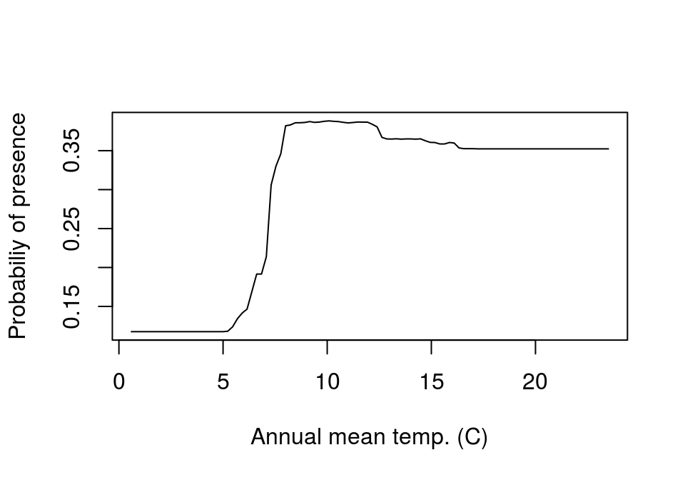

**Relationship between annual mean temperature and probability of presence**

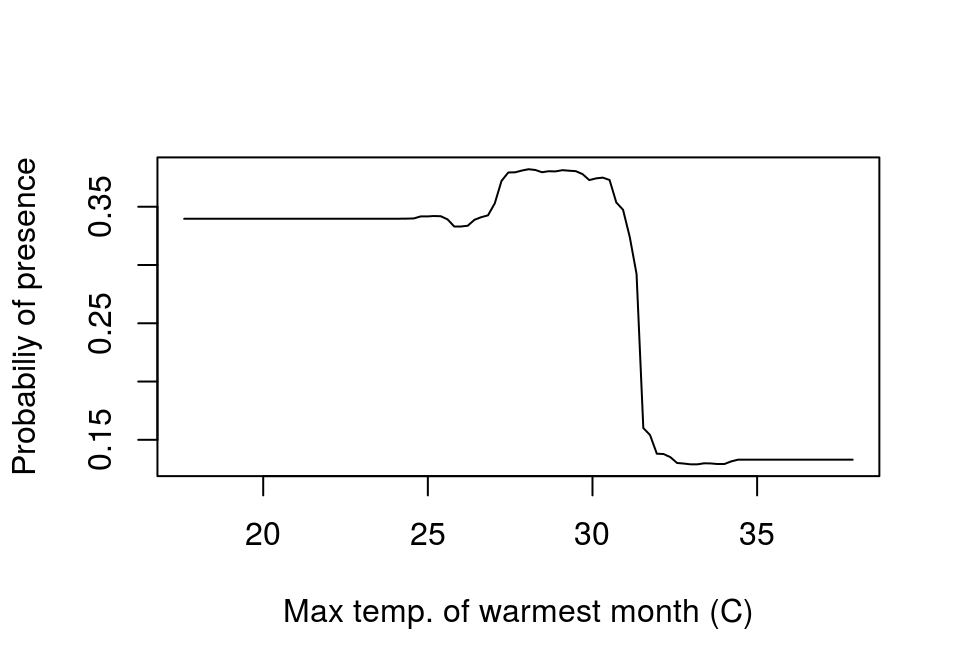

**Relationship between max temp. of warmest month and probability of presence**

#### Parent materials associated with *R. pseudoacacia* presence

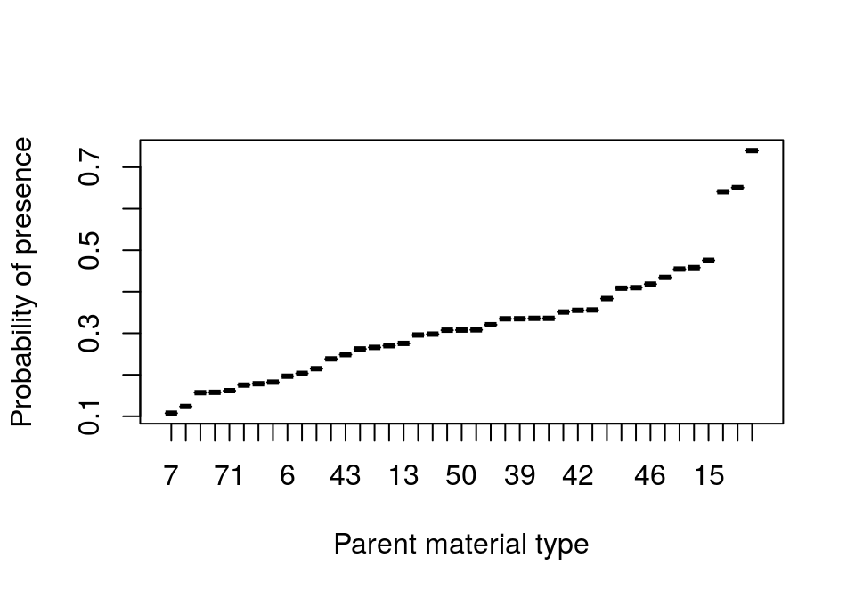

**Relationship between parent material type and probability of presence**

| Parent material type | Probability of *R. pseudoacacia* |
| --- | --- |
| Biotite schist | 74.0% |
| Schist | 65.1% |
| Silt | 64.1% |
| All others | 29.2% |

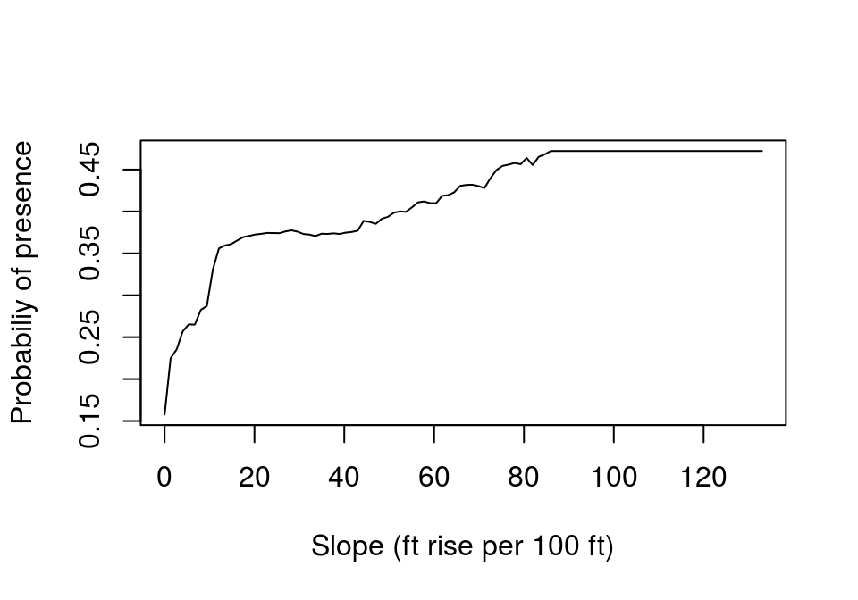

**Relationship between slope and probability of presence**

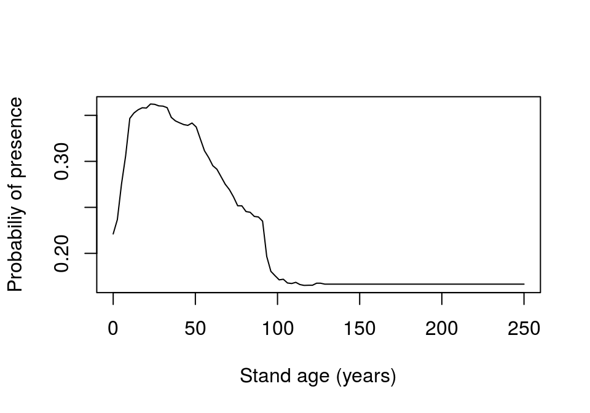

**Relationship between stand age and probability of presence**

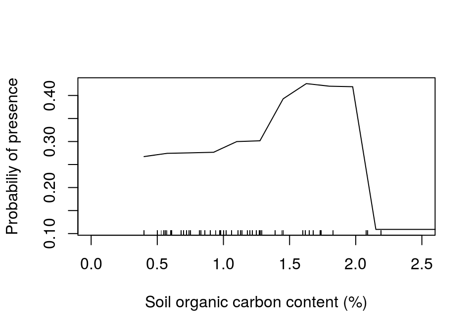

**Relationship between soil organic content and probability of presence**

### Using our model to predict current distribution:

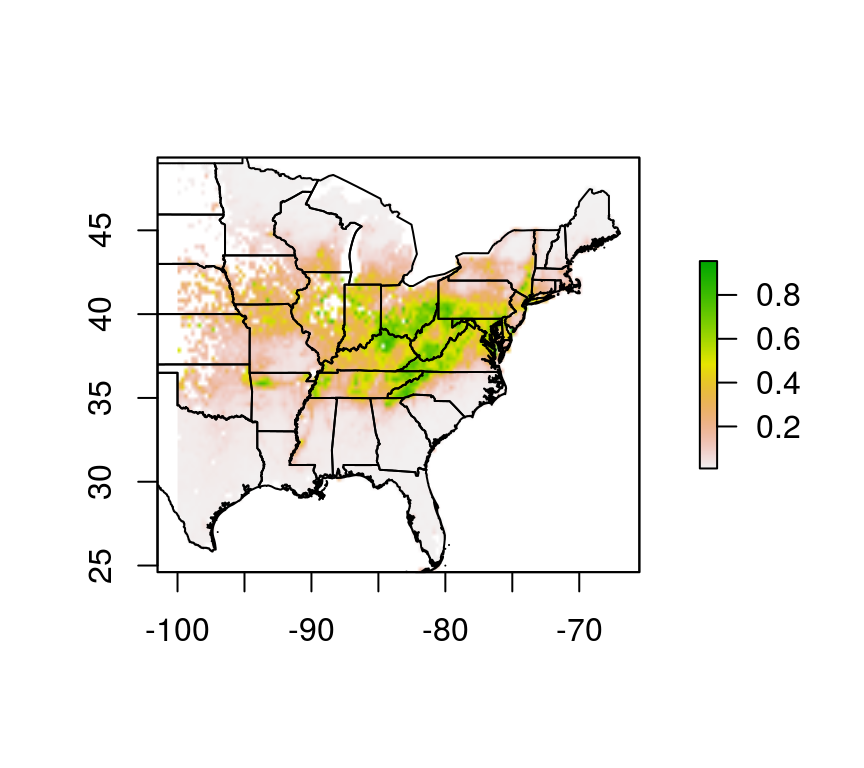

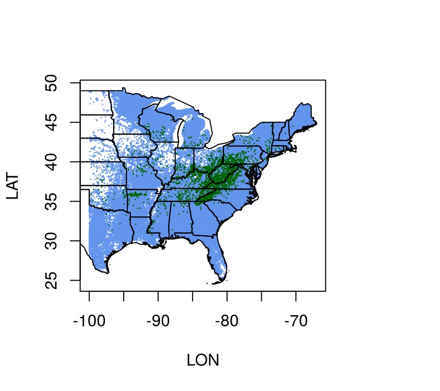

**Predicted probability of presence (left) versus actual distribution (right)**

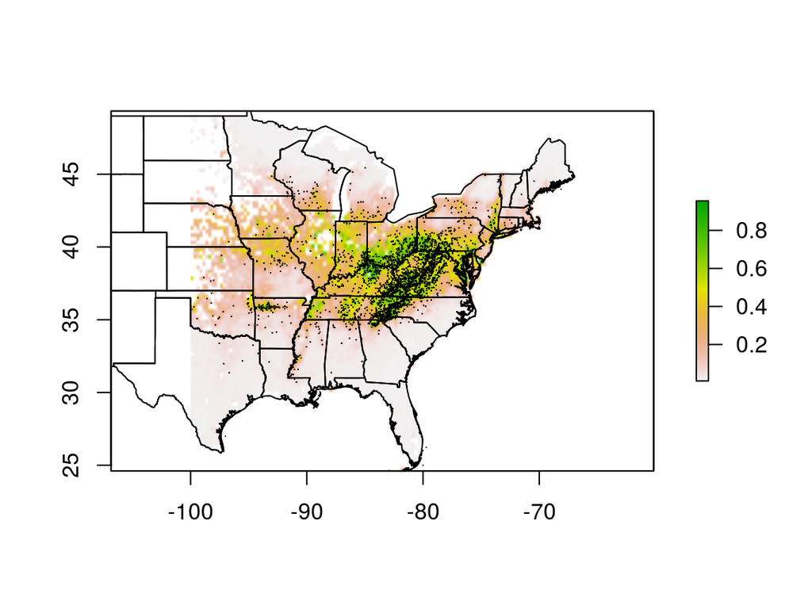

**Plots where *R. pseudoacacia* is present overlaid on predicted probability**

### Using our model to predict distribution in 2050

#### Using the average predictions for 17 GCMs (CMIP5 RCP8.5):

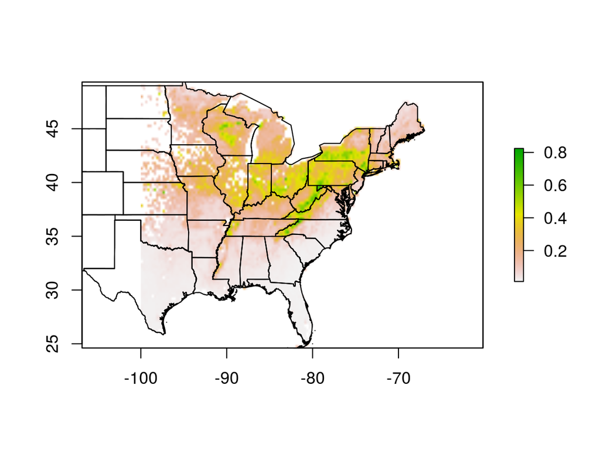

**Predicted probability of presence in 2050**

#### Change from present distribution:

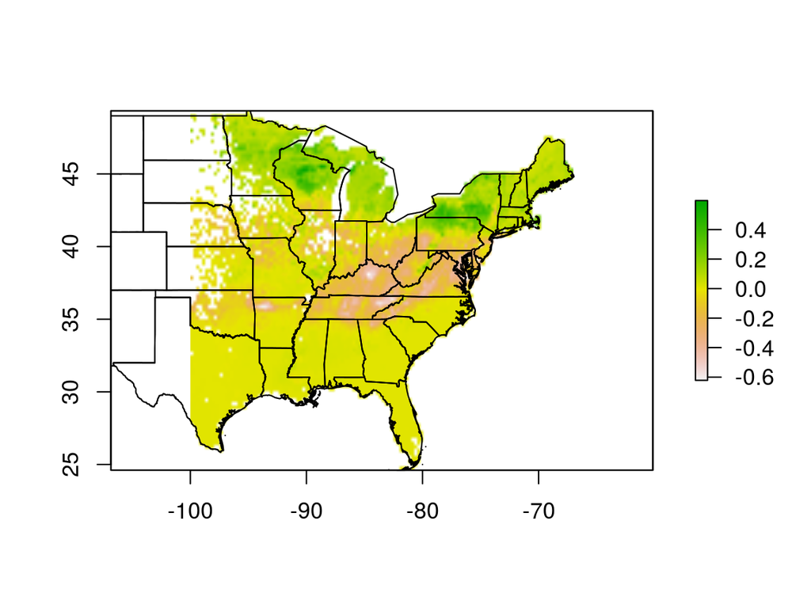

**Change in probability from current to 2050**

## Compare our results to those of other popular models

#### Compare to logistic regression

```
##
## Call:
## NULL
##
## Deviance Residuals:
##     Min       1Q   Median       3Q      Max
## -2.7344  -0.6991   0.1313   0.6623   3.0726
##
## Coefficients: (1 not defined because of singularities)
##                         Estimate Std. Error z value Pr(>|z|)
## (Intercept)            2.743e+01  2.400e+03   0.011 0.990879
## LON                   -2.188e-02  2.226e-02  -0.983 0.325640
## LAT                   -8.437e-01  1.168e-01  -7.223 5.08e-13 ***
## ELEV                  -6.214e-04  1.330e-04  -4.672 2.99e-06 ***
## STDAGE                 1.200e-02  1.397e-03   8.590  < 2e-16 ***
## SLOPE                 -1.697e-02  2.180e-03  -7.786 6.91e-15 ***
## fireYes                4.125e-01  3.008e-01   1.371 0.170308
## asp_val               -1.688e-01  9.481e-02  -1.780 0.075048 .
## bio1                   4.510e-02  5.138e-02   0.878 0.380035
## bio2                   3.925e-02  3.169e-02   1.238 0.215557
## bio3                  -5.580e-01  9.808e-02  -5.689 1.28e-08 ***
## bio4                   8.953e-03  1.728e-03   5.182 2.20e-07 ***
## bio5                   9.413e-02  2.596e-02   3.625 0.000289 ***
## bio6                  -8.778e-02  1.969e-02  -4.458 8.27e-06 ***
## bio7                          NA         NA      NA       NA
## bio8                   4.269e-03  1.139e-03   3.748 0.000179 ***
## bio9                   3.756e-03  9.225e-04   4.071 4.68e-05 ***
## bio10                 -5.048e-01  7.025e-02  -7.187 6.64e-13 ***
## bio11                  3.934e-01  6.526e-02   6.029 1.65e-09 ***
## bio12                 -2.382e-02  2.151e-03 -11.078  < 2e-16 ***
## bio13                  9.187e-02  8.908e-03  10.313  < 2e-16 ***
## bio14                 -5.920e-02  1.302e-02  -4.548 5.42e-06 ***
## bio15                 -2.093e-01  2.445e-02  -8.560  < 2e-16 ***
## bio16                  1.528e-02  5.633e-03   2.713 0.006669 **
## bio17                  5.352e-03  5.624e-03   0.952 0.341295
## bio18                  1.970e-02  3.234e-03   6.091 1.12e-09 ***
## bio19                  2.418e-02  3.329e-03   7.263 3.80e-13 ***
## lith.pred1             1.744e+01  2.400e+03   0.007 0.994201
## lith.pred3             1.823e+01  2.400e+03   0.008 0.993938
## lith.pred5             1.813e+01  2.400e+03   0.008 0.993970
```

[output cut: 92 more lines]

```
## usda_tex10             1.325e-01  6.058e-01   0.219 0.826905
## usda_tex11             3.782e-01  7.345e-01   0.515 0.606576
## usda_tex12            -6.691e-01  6.048e-01  -1.106 0.268528
## OC                     1.359e-01  2.008e-01   0.677 0.498646
## ---
## Signif. codes:  0 '***' 0.001 '**' 0.01 '*' 0.05 '.' 0.1 ' ' 1
##
## (Dispersion parameter for binomial family taken to be 1)
##
##     Null deviance: 10169  on 7406  degrees of freedom
## Residual deviance:  6169  on 7282  degrees of freedom
##   (7076 observations deleted due to missingness)
## AIC: 6419
##
## Number of Fisher Scoring iterations: 15
```